# pleiodb MR control analyses

```python
import sys
sys.path.insert(0, "../src")

import numpy as np
import pandas as pd
import matplotlib.pyplot as plt
import matplotlib.gridspec as gridspec
import scipy.stats
import zstandard, pathlib
from pleiodb.db import GWASDatabase
from pleiodb.quantize import decode_neff, reconstruct_beta_se

db = GWASDatabase.open("/local-scratch/data/pleiodb/main.pleiodb")
traits_meta = pd.read_csv("/local-scratch/data/pleiodb/main.pleiodb/traits.tsv", sep="\t")

eaf     = db.eaf
v_chrom = np.array([v["chrom"] for v in db.variants])
v_pos   = np.array([v["pos"]   for v in db.variants], dtype=np.int64)
v_id    = np.array([v["id"]    for v in db.variants])

Z_THRESH = float(db._z_to_pval_threshold(5e-8))

# --- Imputation lookup (per-trait set of imputed variant indices) ---
coo_path  = pathlib.Path("/local-scratch/data/pleiodb/main.pleiodb/imputed.coo.zst")
_blob     = zstandard.ZstdDecompressor().decompress(coo_path.read_bytes())
_pairs    = np.frombuffer(_blob, dtype=np.uint32).reshape(-1, 2)
_t_order  = np.argsort(_pairs[:, 1], kind="stable")
_t_s, _v_s = _pairs[_t_order, 1], _pairs[_t_order, 0]
_t_bounds = np.searchsorted(_t_s, np.arange(db.T + 1))

def imp_set(t_idx: int) -> set:
    lo, hi = int(_t_bounds[t_idx]), int(_t_bounds[t_idx + 1])
    return set(_v_s[lo:hi].tolist())

def get_gwas(trait_id: str):
    t = int(db.trait_index([trait_id])[0])
    z    = db.zscore_trait(t)
    neff = decode_neff(db._neff.get_block(0, db.V, t, t + 1)[:, 0])
    beta, se = reconstruct_beta_se(z, neff, eaf)
    return t, z, beta, se

def clump_1mb(indices: np.ndarray, z_arr: np.ndarray) -> np.ndarray:
    order = indices[np.argsort(np.abs(z_arr[indices]))[::-1]]
    kept, taken = [], []
    for i in order:
        c, p = v_chrom[i], int(v_pos[i])
        if not any(c == c2 and abs(p - p2) < 1_000_000 for c2, p2 in taken):
            kept.append(int(i)); taken.append((c, p))
    return np.array(kept, dtype=np.int64)

def mr_ivw(bx, by, sy):
    w    = 1.0 / sy ** 2
    beta = np.sum(w * bx * by) / np.sum(w * bx ** 2)
    se   = np.sqrt(1.0 / np.sum(w * bx ** 2))
    pval = 2 * scipy.stats.norm.sf(abs(beta / se))
    return float(beta), float(se), float(pval)

def run_mr(exp_id, out_id, exp_label, out_label, z_cap=100.0):
    exp_t, z_exp, bx_all, sx_all = get_gwas(exp_id)
    out_t, z_out, by_all, sy_all = get_gwas(out_id)

    sig   = np.where(np.abs(z_exp) >= Z_THRESH)[0]
    valid = sig[
        np.isfinite(by_all[sig]) & np.isfinite(bx_all[sig]) &
        (np.abs(z_out[sig]) <= z_cap)
    ]
    cl = clump_1mb(valid, z_exp)

    # flag imputed in either exposure or outcome
    imp_exp = imp_set(exp_t)
    imp_out = imp_set(out_t)
    is_imp  = np.array([v in imp_exp or v in imp_out for v in cl])

    bx = bx_all[cl]; sx = sx_all[cl]
    by = by_all[cl]; sy = sy_all[cl]

    beta, se, pval = mr_ivw(bx, by, sy)

    obs = ~is_imp
    b_obs, s_obs, p_obs = (mr_ivw(bx[obs], by[obs], sy[obs])
                           if obs.sum() > 2 else (np.nan, np.nan, np.nan))
    b_imp, s_imp, p_imp = (mr_ivw(bx[is_imp], by[is_imp], sy[is_imp])
                           if is_imp.sum() > 2 else (np.nan, np.nan, np.nan))

    return dict(
        exp_label=exp_label, out_label=out_label,
        beta=beta, se=se, pval=pval,
        b_obs=b_obs, s_obs=s_obs, p_obs=p_obs,
        b_imp=b_imp, s_imp=s_imp, p_imp=p_imp,
        n_snps=len(cl), n_obs=int(obs.sum()), n_imp=int(is_imp.sum()),
        instruments=pd.DataFrame({
            "alid": v_id[cl], "chrom": v_chrom[cl],
            "beta_exp": bx, "se_exp": sx,
            "beta_out": by, "se_out": sy,
            "imputed": is_imp,
        }),
    )
```

Three established positive controls, each scatter-plot coloured by imputation status (in exposure or outcome). Instruments: GWS hits (p≤5×10⁻⁸), distance-clumped at 1 Mb. Outcome |z|>100 excluded as imputation artefacts (see QC discussion below).

```python
analyses = [
    run_mr("ukb-b-19953",        "ebi-a-GCST006867",  "BMI",            "Type 2 diabetes"),
    run_mr("ebi-a-GCST90018961", "ebi-a-GCST90013864","LDL cholesterol","Coronary artery disease"),
    run_mr("ebi-a-GCST90029011", "ebi-a-GCST90013864","Systolic BP",    "Coronary artery disease"),
]

pd.DataFrame([{
    "Exposure":  a["exp_label"], "Outcome": a["out_label"],
    "n_total": a["n_snps"], "n_observed": a["n_obs"], "n_imputed": a["n_imp"],
    "β_IVW": round(a["beta"], 4), "SE": round(a["se"], 4), "p": f"{a['pval']:.2e}",
} for a in analyses])
```

|  | Exposure | Outcome | n_total | n_observed | n_imputed | β_IVW | SE | p |
| --- | --- | --- | --- | --- | --- | --- | --- | --- |
| 0 | BMI | Type 2 diabetes | 477 | 474 | 3 | 0.7823 | 0.0182 | 0.00e+00 |
| 1 | LDL cholesterol | Coronary artery disease | 136 | 136 | 0 | 0.1156 | 0.0054 | 3.04e-100 |
| 2 | Systolic BP | Coronary artery disease | 415 | 415 | 0 | 0.1929 | 0.0070 | 1.61e-168 |

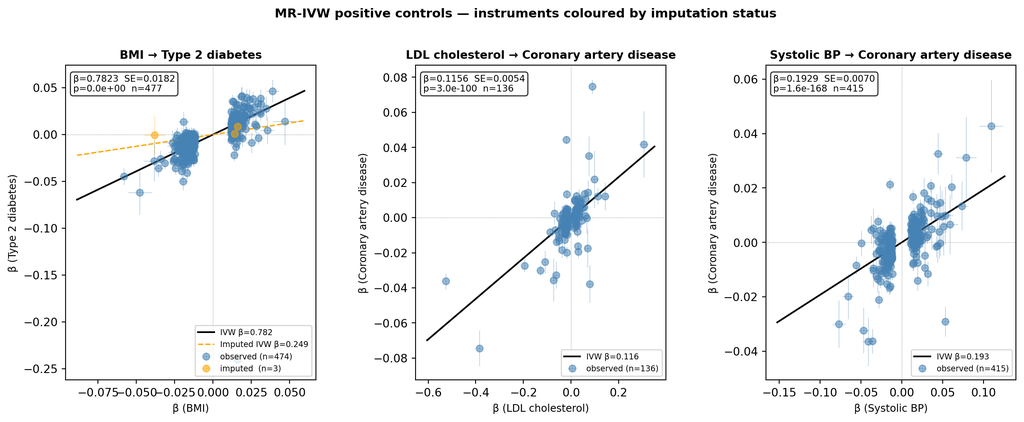

```python
fig = plt.figure(figsize=(15, 5))
gs  = gridspec.GridSpec(1, 3, figure=fig, wspace=0.40)

for col, a in enumerate(analyses):
    ax  = fig.add_subplot(gs[col])
    ins = a["instruments"]
    bx  = ins["beta_exp"].values
    by  = ins["beta_out"].values
    sx  = ins["se_exp"].values
    sy  = ins["se_out"].values
    imp = ins["imputed"].values

    rng = np.random.default_rng(42)
    for mask, col_c, lbl in [
        (~imp, "steelblue", f"observed (n={(~imp).sum()})"),
        ( imp, "orange",    f"imputed  (n={imp.sum()})"),
    ]:
        if mask.sum() == 0:
            continue
        sel = np.where(mask)[0]
        if len(sel) > 300:
            sel = rng.choice(sel, 300, replace=False)
        ax.errorbar(bx[sel], by[sel], xerr=sx[sel], yerr=sy[sel],
                    fmt="o", ms=3 if mask is ~imp else 6,
                    lw=0.3, elinewidth=0.4,
                    color=col_c, alpha=0.55, label=lbl, zorder=2)

    xr = np.array([bx.min() * 1.15, bx.max() * 1.15])
    ax.plot(xr, a["beta"] * xr, "k-", lw=1.5, label=f"IVW β={a['beta']:.3f}")
    if not np.isnan(a["b_imp"]):
        ax.plot(xr, a["b_imp"] * xr, "--", color="orange", lw=1.2,
                label=f"Imputed IVW β={a['b_imp']:.3f}")
    ax.axhline(0, color="grey", lw=0.5, ls=":")
    ax.axvline(0, color="grey", lw=0.5, ls=":")
    ax.set_xlabel(f"β ({a['exp_label']})", fontsize=9)
    ax.set_ylabel(f"β ({a['out_label']})", fontsize=9)
    ax.set_title(f"{a['exp_label']} → {a['out_label']}", fontsize=10, fontweight="bold")
    info = f"β={a['beta']:.4f}  SE={a['se']:.4f}\np={a['pval']:.1e}  n={a['n_snps']}"
    ax.text(0.03, 0.97, info, transform=ax.transAxes,
            va="top", ha="left", fontsize=8,
            bbox=dict(boxstyle="round,pad=0.3", fc="white", alpha=0.8))
    ax.legend(fontsize=7, loc="lower right")

plt.suptitle("MR-IVW positive controls — instruments coloured by imputation status",
             fontsize=11, fontweight="bold", y=1.02)
plt.tight_layout()
plt.show()
```

## Imputed z-score QC

Exploratory checks reveal two classes of problem in imputed values:

**1. Near-sentinel artefacts (|z| ≈ 327.67)**

The int16 missing-data sentinel is −32768 (decoded: −327.68). A handful of imputed variants have raw values of ±32767 (decoded: ±327.67) — one step from NA. These arise when the elastic-net extrapolates far outside the range of the training z-scores and the prediction saturates the int16 ceiling. They produce enormous (and clearly spurious) betas in downstream analyses.

**2. Inflated but sub-threshold z-scores**

**Proposed QC strategy**

| Step | Method | Rationale |
| --- | --- | --- |
| Hard cap during imputation | Clamp predicted z to ±`z_max_obs[t]` — the maximum absolute z observed for that trait | Prevents extrapolation beyond what the study itself supports |
| Flag near-sentinel cells | Mark any imputed cell with `raw int16 > 32700` as suspect | Catches the specific int16 saturation artifact |
| Imputation quality score | Store per-cell elastic-net cross-validation R² | Lets users filter on imputation confidence |
| Per-trait z ceiling | Cap at `min(z_pred, sqrt(neff_study))` — the theoretical maximum z under full heritability | Self-calibrating per study size |

The most practical **immediate fix** is the first: during the imputation pass, after predicting z, apply:

```python
z_imputed = np.clip(z_imputed, -np.nanmax(np.abs(z_observed[t])),
                               +np.nanmax(np.abs(z_observed[t])))
```

This costs nothing, requires no new stored data, and eliminates both artefact classes.

```
Sample: 44,750 imputed z-scores from 100 traits
|z| > 100 : 0  (0.000%)
|z| > 20  : 0  (0.000%)
|z| > 10  : 1  (0.002%)
```

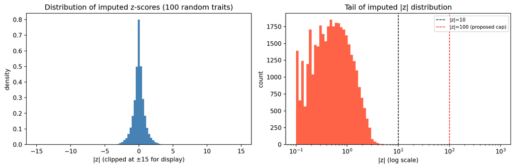

```python
# Illustrate the artefact: distribution of all imputed z-scores for a sample of traits
import random
random.seed(0)
sample_traits = random.sample(range(db.T), 100)

all_imp_z = []
for t in sample_traits:
    lo, hi = int(_t_bounds[t]), int(_t_bounds[t + 1])
    if hi == lo:
        continue
    vs = _v_s[lo:hi]
    z_t = db.zscore_trait(t)
    all_imp_z.extend(z_t[vs][np.isfinite(z_t[vs])].tolist())

all_imp_z = np.array(all_imp_z)
n_art = (np.abs(all_imp_z) > 100).sum()
print(f"Sample: {len(all_imp_z):,} imputed z-scores from 100 traits")
print(f"|z| > 100 : {n_art:,}  ({100*n_art/len(all_imp_z):.3f}%)")
print(f"|z| > 20  : {(np.abs(all_imp_z)>20).sum():,}  ({100*(np.abs(all_imp_z)>20).mean():.3f}%)")
print(f"|z| > 10  : {(np.abs(all_imp_z)>10).sum():,}  ({100*(np.abs(all_imp_z)>10).mean():.3f}%)")

fig, axes = plt.subplots(1, 2, figsize=(12, 4))

bins = np.linspace(-15, 15, 100)
axes[0].hist(np.clip(all_imp_z, -15, 15), bins=bins, color="steelblue",
             edgecolor="none", density=True)
axes[0].set_xlabel("|z| (clipped at ±15 for display)")
axes[0].set_ylabel("density")
axes[0].set_title("Distribution of imputed z-scores (100 random traits)")

axes[1].hist(np.abs(all_imp_z), bins=np.logspace(-1, 3, 80),
             color="tomato", edgecolor="none")
axes[1].set_xscale("log")
axes[1].axvline(10,  color="black", lw=1, ls="--", label="|z|=10")
axes[1].axvline(100, color="red",   lw=1, ls="--", label="|z|=100 (proposed cap)")
axes[1].set_xlabel("|z| (log scale)")
axes[1].set_ylabel("count")
axes[1].set_title("Tail of imputed |z| distribution")
axes[1].legend(fontsize=8)

plt.tight_layout()
plt.show()
```